# The History of the Riches: Timeline of the emerging and steady billionares of the word!

#### Amidst the COVID-19 outbreak where people are recieving stimulus checks at one end for the daily survival we have one sector of the humanity contributing to this give and take relation. This got me thinking into where these people come come and how did they become who they are. The below analysis helped me answer a few of questions.

## Details about the DataSet

- The name of the data set is Billionaires. (Raw Csv format)
- The data set is obtained from CORGIS: The Collection of Really Great, Interesting, Situated Datasets and was compiled by Ryan Whitcomb on 5-17-16
- The daset comprises of the data of super-rich. Building off the Forbes World’s Billionaires lists from 1996-2014, scholars at Peterson Institute for International Economics have added a couple dozen more variables about each billionaire - including whether they were self-made or inherited their wealth. The datset can be downloaded from https://think.cs.vt.edu/corgis/csv/billionaires/
- The copyright belongs to - © 2020 CORGIS Datasets Project. Project by Austin Cory Bart, Dennis Kafura, Clifford A. Shaffer, Javier Tibau, Luke Gusukuma, Eli Tilevich. The dataset is public and can be downloaded and used for personal projects.
- The file is of 594 KB and can be easily downloaded. There are 2614 rows and 22 Columns in the file.

## Characteristics of the dataset

The working code of this analysis can be found on my Github page: https://github.com/nidhip2/nidhip2.github.io/tree/master/Final_Project

## 1st Analysis: The Mean age and Wealth of the Country over the years and the count of billionages based on each country based on a particular sector.

The below interactive graphs gives us the Mean Age of the Billionares in a particular Country and the total weath cumulative of all the billionares in that Country. Further wehn we click on the country we get bifurcation of the billionres in that country based on the sectors from which they get theor income. This analysis helps in figuring out the trend where the maximum number of billionares lie in the world. In addition to that it gives the mean age of the billionares in that region which can be helpful in determining if the regions comprises of yound, old or mid-age billionares. this can be helpful if analyzed with polotical and inherted/non-inherited wealth in that region. Also, it gives us the count of billionares in each sectors over the years and this will be helpful in determining the more profiting industries and markets. Also it can be helpful in determining the influence of billionares in those market ares (negative or positive).

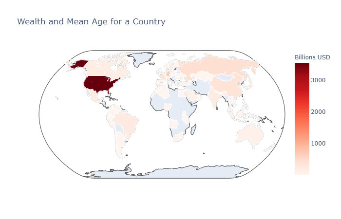

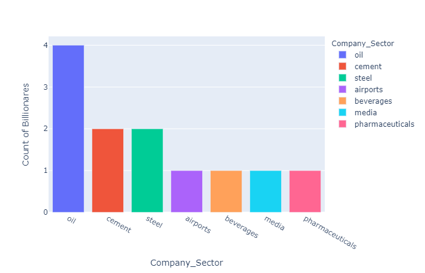

The insipration of this analysis was from an article: Visualizing The World’s Top 50 Wealthiest Billionaires by Jeff Desjardins. Below is an extract from the article which take sthe data from the Forbes Billionare list and segregates the list by 50 Billionares based on Insdustry type. Here he seggregates the data based on the sector and ranks them and listes the top billionares in that sector. The ranking of these billionares is based on the size of the hexagon.

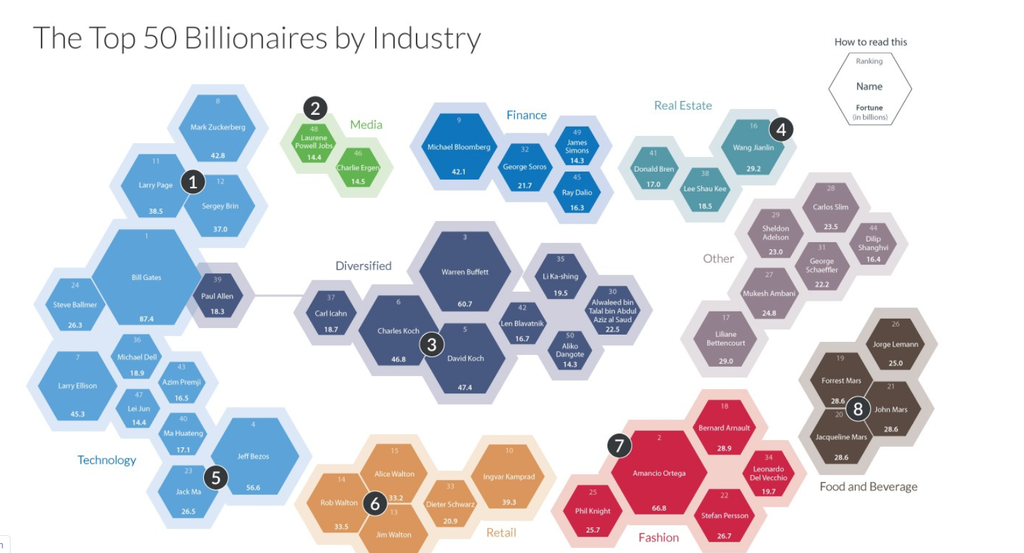

Similarly he also describes how much wealth a particular country has by comparing the GDP of the billionares with the GDP of the various states and Countries in the world. And the result is astonsihing!

[figure not shown]

## 2nd Analysis: Here I have analysed the top 100 billionares and their age based on their Region for a particular year

The below graphs are for the year 1996, 2001 and 2014 and shows the count of billionares based on Regiona and their ages. When copmared we can see that "Sub-Saharan Africa" and "South Asia" had no billionares in 1996 but they had increased count in the year 2014 an 2001. Also the count in the regions cahnges drastically from 2001 to 2014 as we can see on the labels.

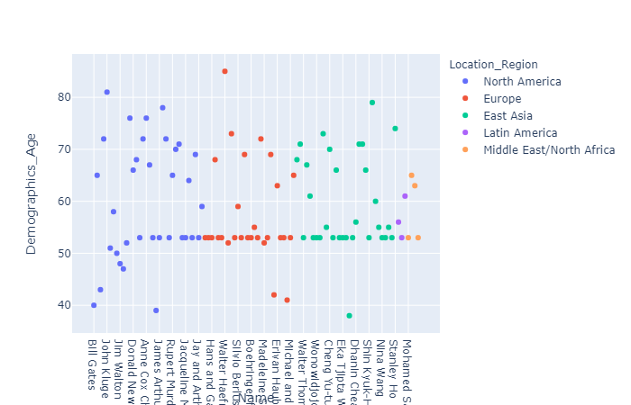

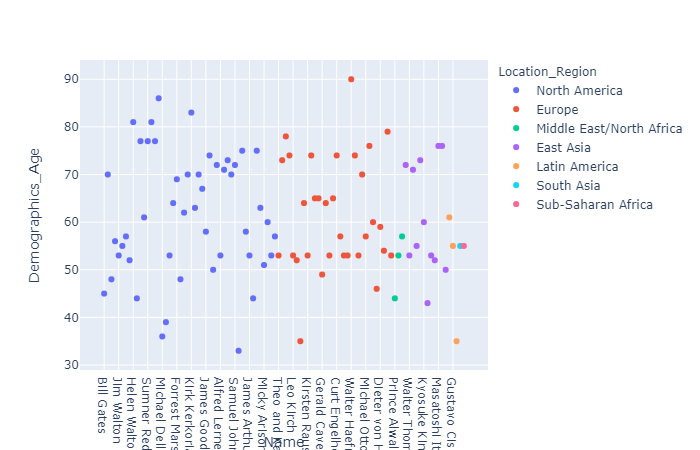

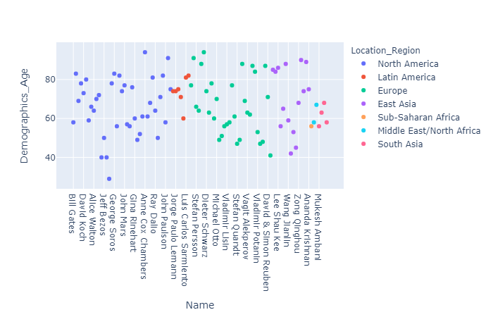

Again as in the Jeff's artice for 2016 data he demestrated the citizens where the maximum number of billionares reside and a background on the richest people in that region.

[figure not shown]

https://mybinder.org/v2/gh/nidhip2/nidhip2.github.io/master

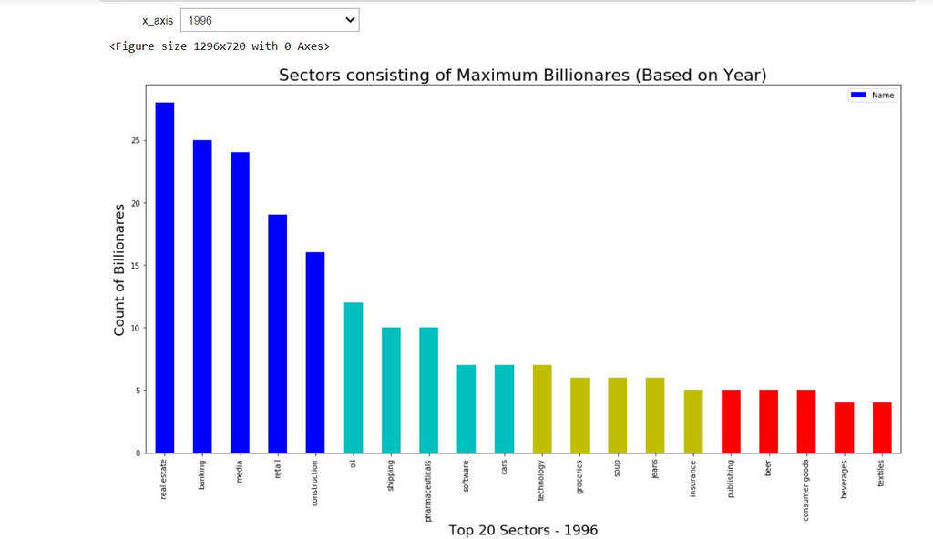

## Conclusion

There is alot of scope for improvements in the above anlysis. I wish to integrate the 2018 forbes data with existing file to derive strong comaprisons in the trends over the past decade. Also there are a few more factors like gender, wealth type and politics. Bew are the cited reference and Binder link for the artice code.

## #References

1.https://www.piie.com/system/files/documents/wp16-1.pdf

2.https://www.piie.com/publications/working-papers/origins-superrich-billionaire-characteristics-database

3.https://howmuch.net/articles/richest-billionaires-by-country-2019

4.https://www.visualcapitalist.com/visualizing-worlds-top-50-wealthiest-billionaires/

5.https://boingboing.net/2019/11/22/visualizing-just-how-stupidly.html

6.https://www.forbes.com/billionaires/

7.https://medium.com/@powusu381/a-complete-data-analysis-walk-through-with-pythons-pandas-matplotlib-and-seaborn-2df9f6a3035b

8.https://knoema.com/yrdcubc/forbes-world-s-billionaires

9.https://plotly.com/python/plotly-fundamentals/

10.https://www.visualcapitalist.com/visualizing-worlds-top-50-wealthiest-billionaires/

11.https://www.forbes.com/billionaires/

12.https://howmuch.net/articles/richest-billionaires-by-country-2019